# Duração de mandato nas Secretarias Estaduais de Saúde

uma análise de como o gênero afeta o tempo dos mandatos nas regiões brasileiras

Alexandra Emanuela Novais Silva

2024-09-04

# Apresentação

Nesse documento, nós analisamos a duração de mandato de secretários de saúde estaduais do Brasil durante 10 anos, de 2006 a 2016. Esse cargo faz parte da burocracia de alto escalão subnacional e é comissionado, ou seja, indicado pelos governadores estaduais. Cada estado possui um secretario estadual desaúde. É importante ressaltar que,a base de dados foi construída manualmente pelos autores, por meio de levantamento documental. Isso ocorreu devido a ausência de uma base consolidada disponível para acesso público.

# Análises

## Pacotes

Instalar os seguintes pacotes:

```r
install.packages("readxl")
install.packages("dplyr")
install.packages("lubridate")
install.packages("ggplot2")
install.packages("knitr")
install.packages("rmarkdown")
install.packages("TeachingDemos")
```

Carregar os seguintes pacotes:

```r
library(readxl)
library(dplyr)
library(lubridate)
library(ggplot2)
library(TeachingDemos)
```

# Selecionando dados de intesse

Aqui definimos as variáveis de duração dos mandatos como númericas, criamos a coluna duração do mandato e criamos a coluna Regiao. A última servirá para agregarmos dados de todas as regiões.

```r
prepare_data <- function(df, nome_regiao) {df %>%
mutate( Mandato_Inicio =
as.numeric(Mandato_Inicio), Mandato_Final = as.numeric(Mandato_Final),
duracao_mandato = (Mandato_Final - Mandato_Inicio) + 1 ) %>%
select(Gênero, duracao_mandato) %>% mutate(nome_regiao)}
```

Também juntamos os dados das regiões para posteriormente apresentarmos os dados conjuntos por região de forma agregada.

```r
secretarios_combinados <- bind_rows(
  prepare_data(Secretarios_de_saude_CO, "Centro-Oeste"),
  prepare_data(Secretarios_de_saude_Norte, "Norte"),
  prepare_data(Secretarios_de_saude_Nordeste, "Nordeste"),
  prepare_data(Secretarios_de_saude_Sudeste, "Sudeste"),
  prepare_data(Secretarios_de_saude_Sul,"Sul"))
```

Agora omitimos dados que que possuem valores ausentes:

```r
secretarios_combinados <- na.omit(secretarios_combinados)
```

# Intervalo de Confiança

Agora criamos um dataframe chamado intervalo de confiança com as variáveis: media da duração do mandato; variância da duração do mandato; a raiz da variância, que é igual ao desvio padrão; o n, que refe-se ao tamanho da amostra;e o erro padrão.Todas essas são calculadas referentes a cada região e ao gênero.

```r
intervalo_confiança <- secretarios_combinados %>%
  group_by(Gênero, nome_regiao) %>%
  summarise( media = mean(duracao_mandato, na.rm = TRUE),
    variancia = var(duracao_mandato, na.rm = TRUE),
    raiz_variancia = sqrt(variancia),
    n = n(),
    erro_padrao = sqrt(variancia) / sqrt(n))
```

## Calculando a Margem de Erro

Aqui criamos uma coluna para margem de erro dentro do dataframe e o calculamos.

```r
margem_erro <- intervalo_confiança %>%
  mutate(
    margem_erro = qt (0.975, df = n - 1) * erro_padrao)
```

Calculando os limites inferior e superior e criando uma coluna para margem de erro.

```r
intervalo_confiança <- margem_erro %>%
  mutate(
    limite_inferior = media - margem_erro,
    limite_superior = media + margem_erro)
```

# Resultado do Intervalo de Confiança

```
## # A tibble: 9 × 10
## # Groups:   Gênero [2]
##   Gênero nome_regiao  media variancia raiz_variancia     n erro_padrao
##   <chr>  <chr>        <dbl>     <dbl>          <dbl> <int>       <dbl>
## 1 F      Centro-Oeste  3.2      5.7            2.39      5       1.07
## 2 F      Nordeste      1.92     0.992          0.996    12       0.288
## 3 F      Norte         2.3      0.9            0.949    10       0.3
## 4 F      Sul           3        7              2.65      3       1.53
## 5 M      Centro-Oeste  1.93     1.38           1.17     27       0.226
## 6 M      Nordeste      2.58     2.42           1.56     48       0.224
## 7 M      Norte         2.02     2.07           1.44     42       0.222
## 8 M      Sudeste       2.68     3.56           1.89     19       0.433
## 9 M      Sul           2.14     1.21           1.10     14       0.294
## # ℹ 3 more variables: margem_erro <dbl>, limite_inferior <dbl>,
## #   limite_superior <dbl>
```

# Gráfico

Agora, geramos o gráfico de intervalo de confiança, já que temos os dados que precisamos. Como olhamos para gênero e duração do madatos, estes dados serão apresentados em conjunto.

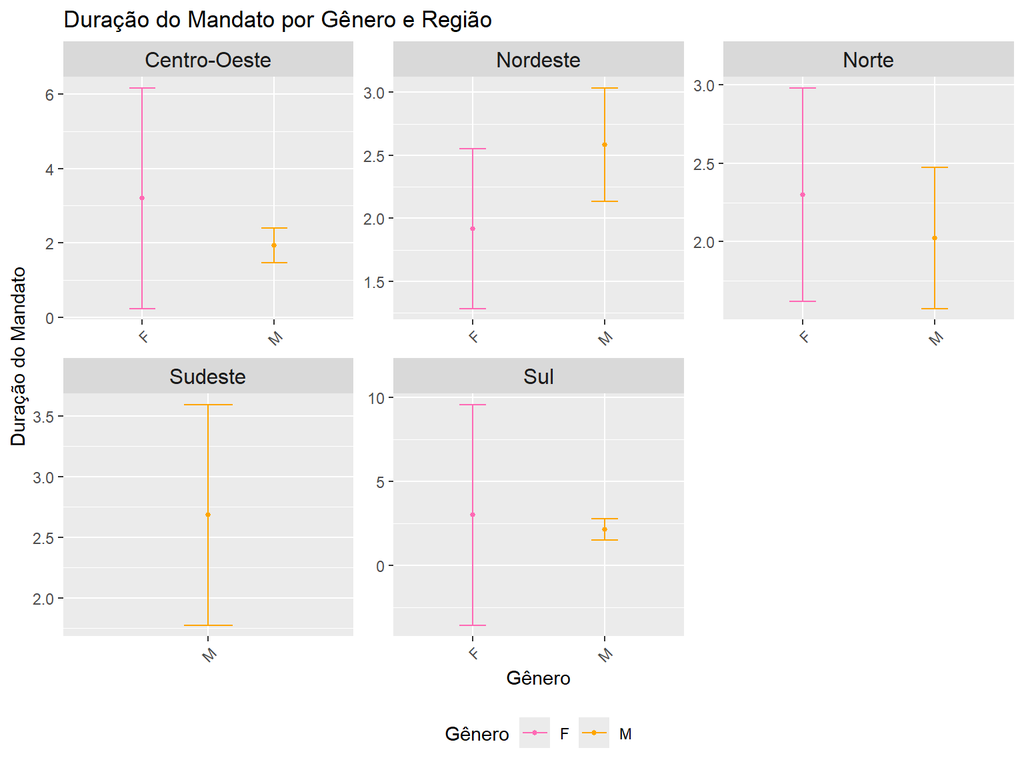

# Hipótese

Nossa hipótese é de que independente da região, as mulheres tendem a ter mandatos menores.